# Análise de Regressão: Sono em Mamiferos

16-11-2025

# Membros do grupo

Carolina Penido Barcellos Gabrielly Xavier dos Santos Matheus Soares dos Santos de Freitas

# Introdução

Este trabalho consiste em analisar o **tempo total de sono dos mamíferos** (`total_sleep`), buscando compreender quais variáveis biológicas e comportamentais explicam essa característica.

- **Variável Resposta (Y):** `total_sleep` (Horas totais de sono por dia).
- **Variáveis Explicativas (X) Consideradas:**
  - `species` – Espécie do mamífero.
  - `body_wt` – Peso corporal total do mamífero (em kg).
  - `brain_wt` – Peso do cérebro do mamífero (em kg).
  - `life_span` – Expectativa de vida do mamífero (em anos).
  - `gestation` – Duração média da gestação (em dias).
  - `predation` – Índice de probabilidade de o mamífero ser predado.
    - 1 = menos provável de ser predado, 5 = mais provável de ser predado.
  - `exposure` – Índice de exposição do mamífero durante o sono.
    - 1 = menos exposto (ex.: dorme em abrigo), 5 = mais exposto (ex.: dorme em local aberto).
  - `danger` – Índice geral de perigo enfrentado, baseado nos índices `predation` e `exposure`.
    - 1 = menor perigo, 5 = maior perigo.

```r
install.packages("readr")
install.packages("car")
install.packages("dplyr")
```

```r
install.packages("ggplot2")
install.packages("tidyr")
library(car)
library(readr)
library(dplyr)
library(ggplot2)
library(tidyr)

mammals <- read_csv("dataset/mammals.csv")
mammals_clean <- mammals %>%
  drop_na(species, body_wt, brain_wt, non_dreaming, dreaming,
          total_sleep, life_span, gestation, predation, exposure, danger)
```

# Estatísticas descritivas

```r
summary(mammals)
```

```
##    species             body_wt            brain_wt        non_dreaming
##  Length:62          Min.   :   0.005   Min.   :   0.14   Min.   : 2.100
##  Class :character   1st Qu.:   0.600   1st Qu.:   4.25   1st Qu.: 6.250
##  Mode  :character   Median :   3.342   Median :  17.25   Median : 8.350
##                     Mean   : 198.790   Mean   : 283.13   Mean   : 8.673
##                     3rd Qu.:  48.203   3rd Qu.: 166.00   3rd Qu.:11.000
##                     Max.   :6654.000   Max.   :5712.00   Max.   :17.900
##                                                          NA's   :14
##     dreaming      total_sleep      life_span         gestation
##  Min.   :0.000   Min.   : 2.60   Min.   :  2.000   Min.   : 12.00
##  1st Qu.:0.900   1st Qu.: 8.05   1st Qu.:  6.625   1st Qu.: 35.75
##  Median :1.800   Median :10.45   Median : 15.100   Median : 79.00
##  Mean   :1.972   Mean   :10.53   Mean   : 19.878   Mean   :142.35
##  3rd Qu.:2.550   3rd Qu.:13.20   3rd Qu.: 27.750   3rd Qu.:207.50
##  Max.   :6.600   Max.   :19.90   Max.   :100.000   Max.   :645.00
##  NA's   :12      NA's   :4       NA's   :4         NA's   :4
##    predation        exposure         danger
##  Min.   :1.000   Min.   :1.000   Min.   :1.000
##  1st Qu.:2.000   1st Qu.:1.000   1st Qu.:1.000
##  Median :3.000   Median :2.000   Median :2.000
##  Mean   :2.871   Mean   :2.419   Mean   :2.613
##  3rd Qu.:4.000   3rd Qu.:4.000   3rd Qu.:4.000
##  Max.   :5.000   Max.   :5.000   Max.   :5.000
##
```

Dado que estamso tratando de regressão, é desejável que nossa variável resposta siga a distribuição normal, dado que isso aumentaria as chances dos nossos erros também serem normais. Portanto, é válido, começar analisando isso.

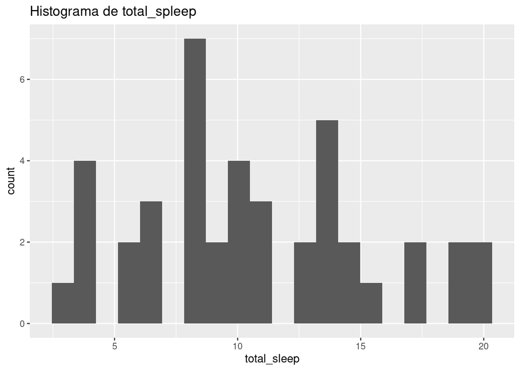

```r
print(
    ggplot(mammals_clean, aes_string('total_sleep')) +
      geom_histogram(bins = 20) +
      ggtitle(paste("Histograma de total_spleep"))
  )
```

O histograma do total_sleep mostra que os dados não têm uma distribuição normal (“curva de sino”) e parecem ter vários picos (multimodal), sugerindo que há subgrupos diferentes de mamíferos.

Isso não é um problema agora, mas reforça que, depois de criar o modelo, será fundamental verificar se os resíduos (os erros) são normais, pois essa é a suposição principal da regressão.

# Testando se há correlação entre as variáveis explicativas (Indício de Multicolinearidade)

```r
#Testando se há correlação linear entre as variáveis body_wt e brain_wt
cor.test(mammals_clean$body_wt, mammals_clean$brain_wt, method = "pearson")
```

```
##
##  Pearson's product-moment correlation
##
## data:  mammals_clean$body_wt and mammals_clean$brain_wt
## t = 20.572, df = 40, p-value < 2.2e-16
## alternative hypothesis: true correlation is not equal to 0
## 95 percent confidence interval:
##  0.9188566 0.9761860
## sample estimates:
##       cor
## 0.9558487
```

```r
#Testando se há correlação linear entre as variáveis exposure e danger
cor.test(mammals_clean$exposure, mammals_clean$danger, method = "pearson")
```

```
##
##  Pearson's product-moment correlation
##
## data:  mammals_clean$exposure and mammals_clean$danger
## t = 8.144, df = 40, p-value = 5.048e-10
## alternative hypothesis: true correlation is not equal to 0
## 95 percent confidence interval:
##  0.6393497 0.8820136
## sample estimates:
##      cor
## 0.789807
```

```r
#Testando se há correlação linear entre as variáveis dreaming e non_dreaming
cor.test(mammals_clean$dreaming, mammals_clean$non_dreaming, method = "pearson")
```

```
##
##  Pearson's product-moment correlation
##
## data:  mammals_clean$dreaming and mammals_clean$non_dreaming
## t = 3.8325, df = 40, p-value = 0.0004388
## alternative hypothesis: true correlation is not equal to 0
## 95 percent confidence interval:
##  0.2543788 0.7102954
## sample estimates:
##       cor
## 0.5182429
```

```r
#Testando se há correlação linear entre as variáveis predation e exposure
cor.test(mammals_clean$predation, mammals_clean$exposure, method = "pearson")
```

```
##
##  Pearson's product-moment correlation
##
## data:  mammals_clean$predation and mammals_clean$exposure
## t = 5.0728, df = 40, p-value = 9.384e-06
## alternative hypothesis: true correlation is not equal to 0
## 95 percent confidence interval:
##  0.3973114 0.7810834
## sample estimates:
##       cor
## 0.6256876
```

```r
#Testando se há correlação linear entre as variáveis predation e danger
cor.test(mammals_clean$predation, mammals_clean$danger, method = "pearson")
```

```
##
##  Pearson's product-moment correlation
##
## data:  mammals_clean$predation and mammals_clean$danger
## t = 15.67, df = 40, p-value < 2.2e-16
## alternative hypothesis: true correlation is not equal to 0
## 95 percent confidence interval:
##  0.8680331 0.9605316
## sample estimates:
##       cor
## 0.9273173
```

# Correlação entre a variável resposta e cada variável independente.

```r
#Testando se há correlação linear entre as variáveis total_sleep e danger
cor.test(mammals_clean$total_sleep, mammals_clean$danger, method = "pearson")
```

```
##
##  Pearson's product-moment correlation
##
## data:  mammals_clean$total_sleep and mammals_clean$danger
## t = -4.7969, df = 40, p-value = 2.257e-05
## alternative hypothesis: true correlation is not equal to 0
## 95 percent confidence interval:
##  -0.7673058 -0.3679520
## sample estimates:
##        cor
## -0.6043029
```

```r
#Testando se há correlação linear entre as variáveis total_sleep e exposure
cor.test(mammals_clean$total_sleep, mammals_clean$exposure, method = "pearson")
```

```
##
##  Pearson's product-moment correlation
##
## data:  mammals_clean$total_sleep and mammals_clean$exposure
## t = -5.0155, df = 40, p-value = 1.127e-05
## alternative hypothesis: true correlation is not equal to 0
## 95 percent confidence interval:
##  -0.7783060 -0.3913289
## sample estimates:
##        cor
## -0.6213578
```

```r
#Testando se há correlação linear entre as variáveis total_sleep e dreaming
cor.test(mammals_clean$total_sleep, mammals_clean$dreaming, method = "pearson")
```

```
##
##  Pearson's product-moment correlation
##
## data:  mammals_clean$total_sleep and mammals_clean$dreaming
## t = 6.5088, df = 40, p-value = 9.112e-08
## alternative hypothesis: true correlation is not equal to 0
## 95 percent confidence interval:
##  0.5284426 0.8383731
## sample estimates:
##       cor
## 0.7171864
```

```r
#Testando se há correlação linear entre as variáveis total_sleep e non_dreaming
cor.test(mammals_clean$total_sleep, mammals_clean$non_dreaming, method = "pearson")
```

```
##
##  Pearson's product-moment correlation
##
## data:  mammals_clean$total_sleep and mammals_clean$non_dreaming
## t = 24.266, df = 40, p-value < 2.2e-16
## alternative hypothesis: true correlation is not equal to 0
## 95 percent confidence interval:
##  0.9402854 0.9826121
## sample estimates:
##      cor
## 0.967673
```

```r
#Testando se há correlação linear entre as variáveis total_sleep e body_wt
cor.test(mammals_clean$total_sleep, mammals_clean$body_wt, method = "pearson")
```

```
##
##  Pearson's product-moment correlation
##
## data:  mammals_clean$total_sleep and mammals_clean$body_wt
## t = -2.3082, df = 40, p-value = 0.02624
## alternative hypothesis: true correlation is not equal to 0
## 95 percent confidence interval:
##  -0.58573561 -0.04343148
## sample estimates:
##        cor
## -0.3428373
```

```r
#Testando se há correlação linear entre as variáveis total_sleep e brain_wt
cor.test(mammals_clean$total_sleep, mammals_clean$brain_wt, method = "pearson")
```

```
##
##  Pearson's product-moment correlation
##
## data:  mammals_clean$total_sleep and mammals_clean$brain_wt
## t = -2.2644, df = 40, p-value = 0.02904
## alternative hypothesis: true correlation is not equal to 0
## 95 percent confidence interval:
##  -0.58144413 -0.03693403
## sample estimates:
##        cor
## -0.3370815
```

```r
#Testando se há correlação linear entre as variáveis total_sleep e predation
cor.test(mammals_clean$total_sleep, mammals_clean$predation, method = "pearson")
```

```
##
##  Pearson's product-moment correlation
##
## data:  mammals_clean$total_sleep and mammals_clean$predation
## t = -2.7991, df = 40, p-value = 0.007849
## alternative hypothesis: true correlation is not equal to 0
## 95 percent confidence interval:
##  -0.6310269 -0.1149199
## sample estimates:
##        cor
## -0.4047155
```

```r
#Testando se há correlação linear entre as variáveis total_sleep e life_span
cor.test(mammals_clean$total_sleep, mammals_clean$life_span, method = "pearson")
```

```
##
##  Pearson's product-moment correlation
##
## data:  mammals_clean$total_sleep and mammals_clean$life_span
## t = -2.6178, df = 40, p-value = 0.01243
## alternative hypothesis: true correlation is not equal to 0
## 95 percent confidence interval:
##  -0.61490284 -0.08884152
## sample estimates:
##        cor
## -0.3824462
```

```r
#Testando se há correlação linear entre as variáveis total_sleep e gestation
cor.test(mammals_clean$total_sleep, mammals_clean$gestation, method = "pearson")
```

```
##
##  Pearson's product-moment correlation
##
## data:  mammals_clean$total_sleep and mammals_clean$gestation
## t = -4.926, df = 40, p-value = 1.499e-05
## alternative hypothesis: true correlation is not equal to 0
## 95 percent confidence interval:
##  -0.7738778 -0.3818580
## sample estimates:
##        cor
## -0.6144743
```

#Heatmap de correlação

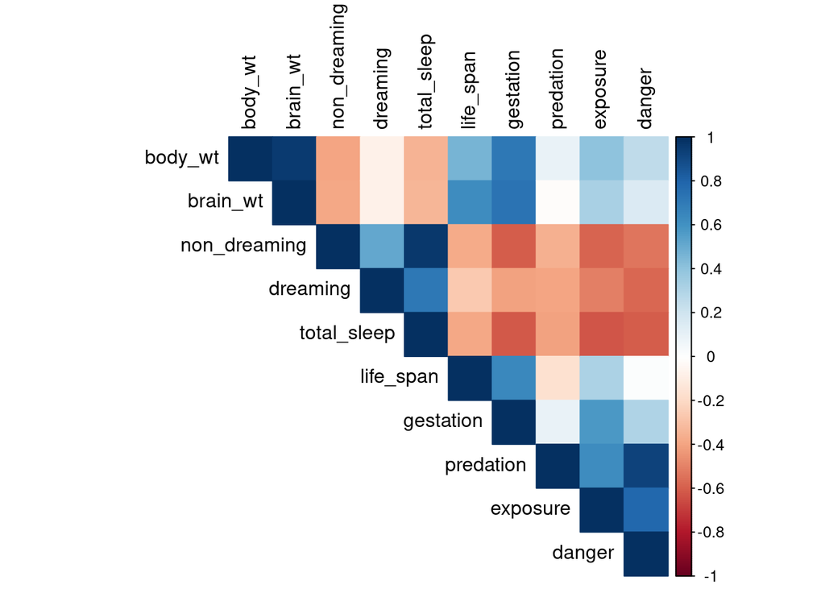

```r
library(corrplot)
cor_matrix <- cor(mammals_clean |> select(-species), use = "complete.obs")

corrplot(
  cor_matrix,
  method = "color",
  type = "upper",
  tl.col = "black",
  addCoef.col = NULL,
  number.cex = 0,
  cl.pos = "r"
)
```

# Histogramas das variáveis numéricas

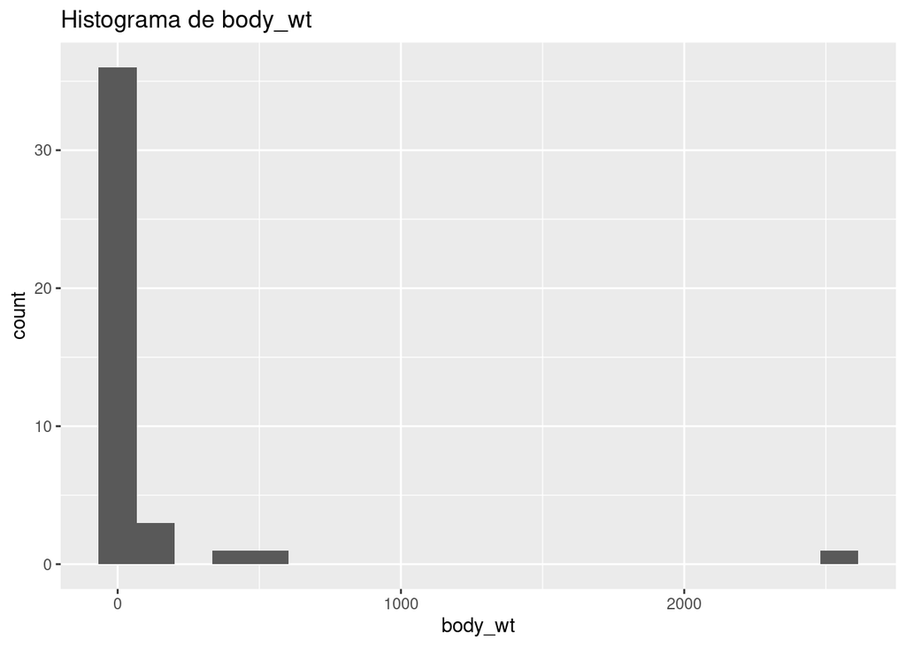

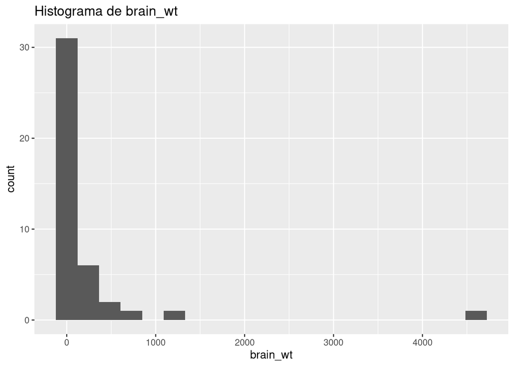

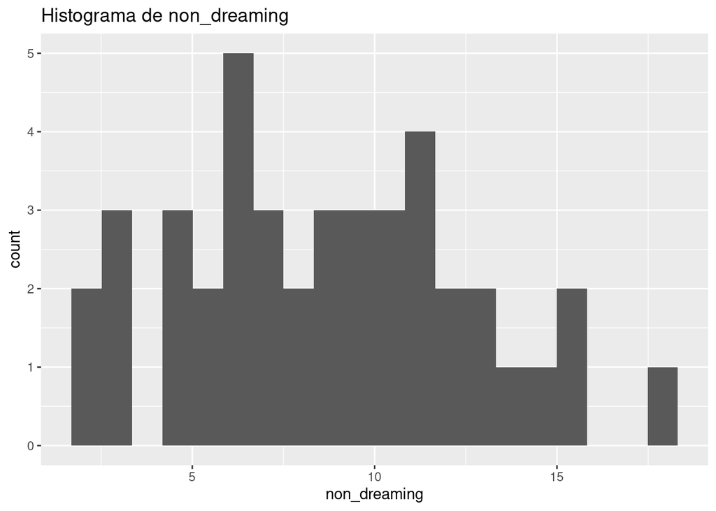

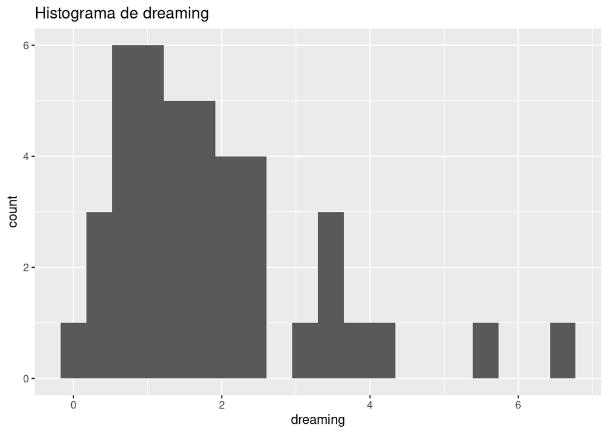

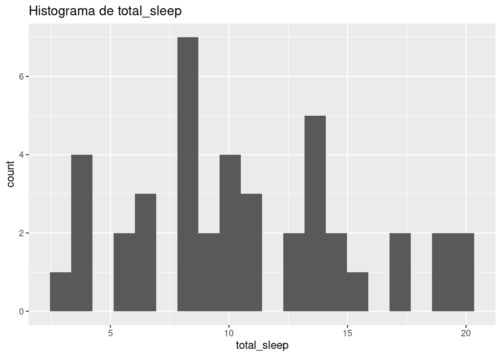

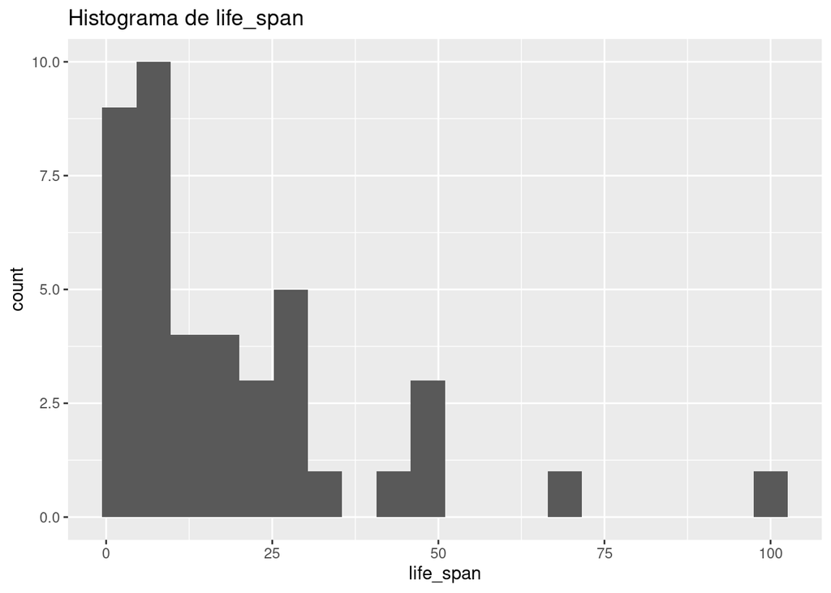

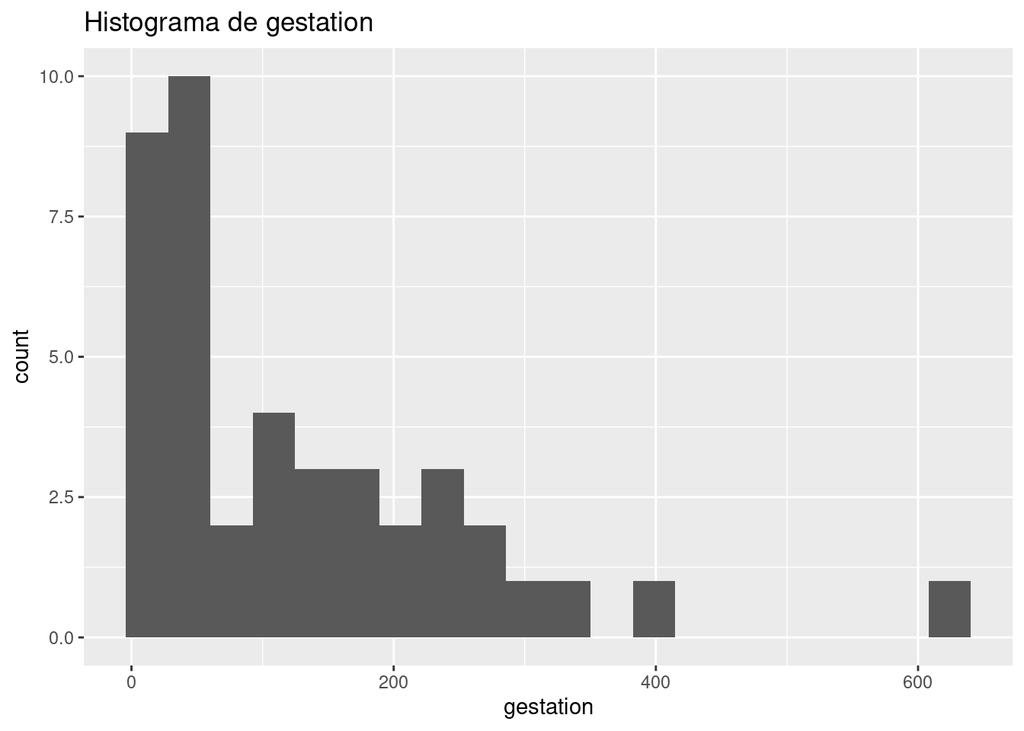

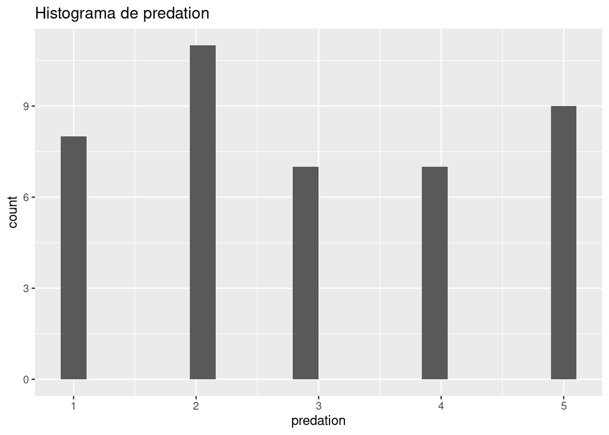

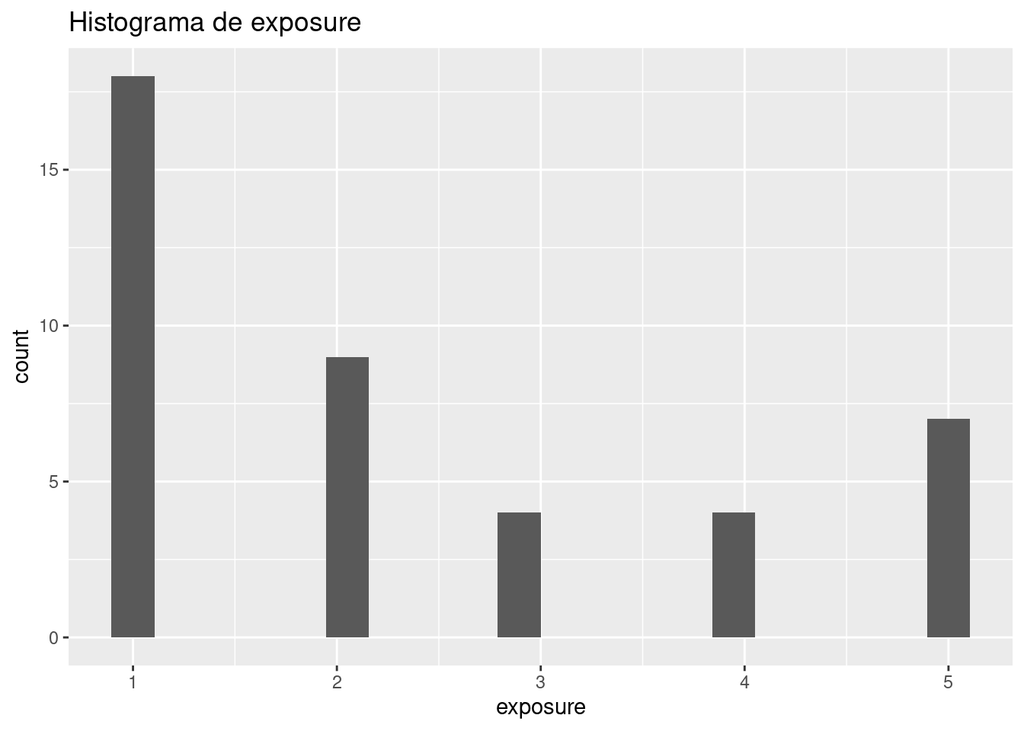

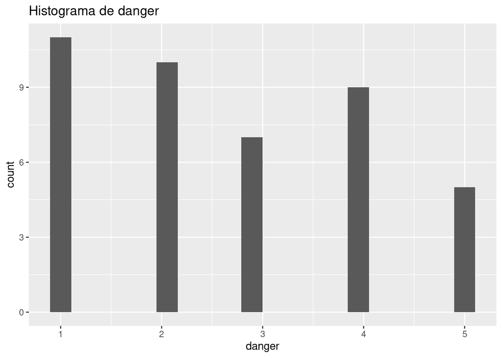

```r
numeric_vars <- mammals_clean |> dplyr::select(-species)

for(col in names(numeric_vars)){
  print(
    ggplot(mammals_clean, aes_string(col)) +
      geom_histogram(bins = 20) +
      ggtitle(paste("Histograma de", col))
  )
}
```

# Boxplot das variáveis numéricas para ver outliers

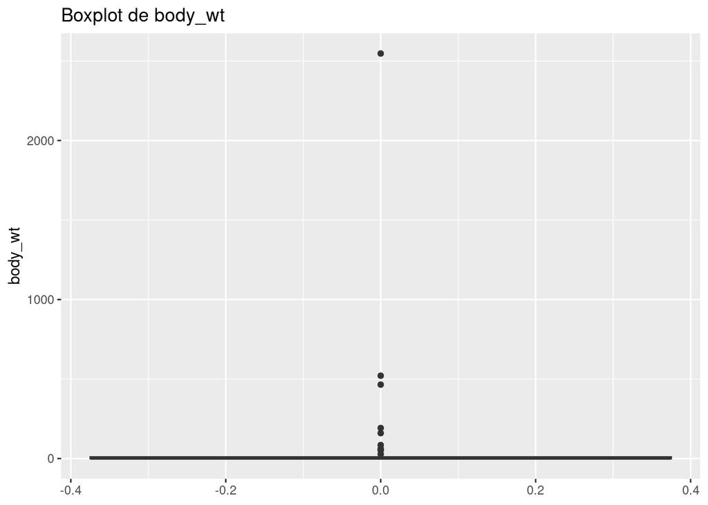

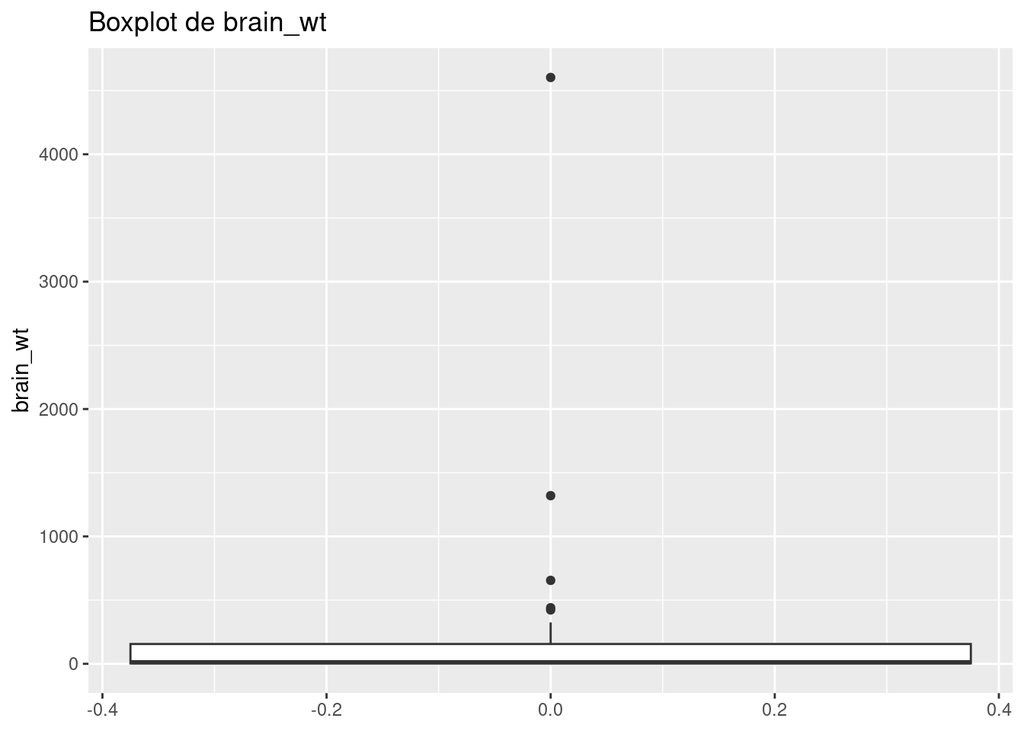

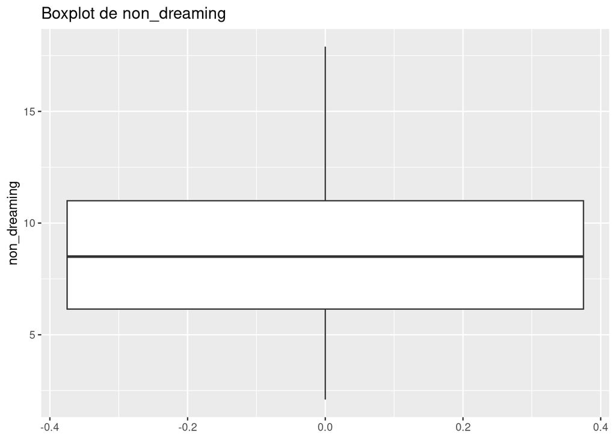

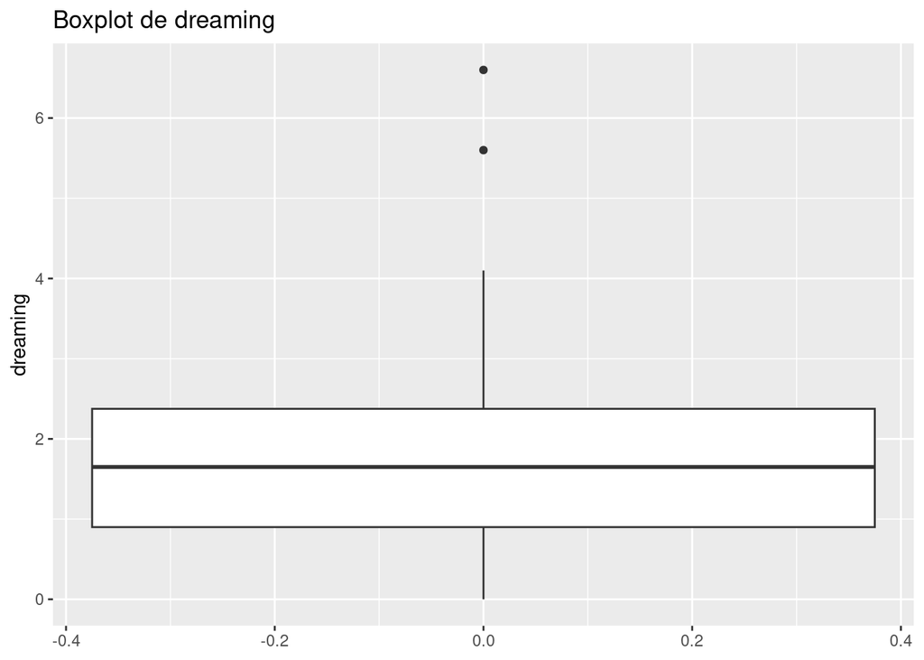

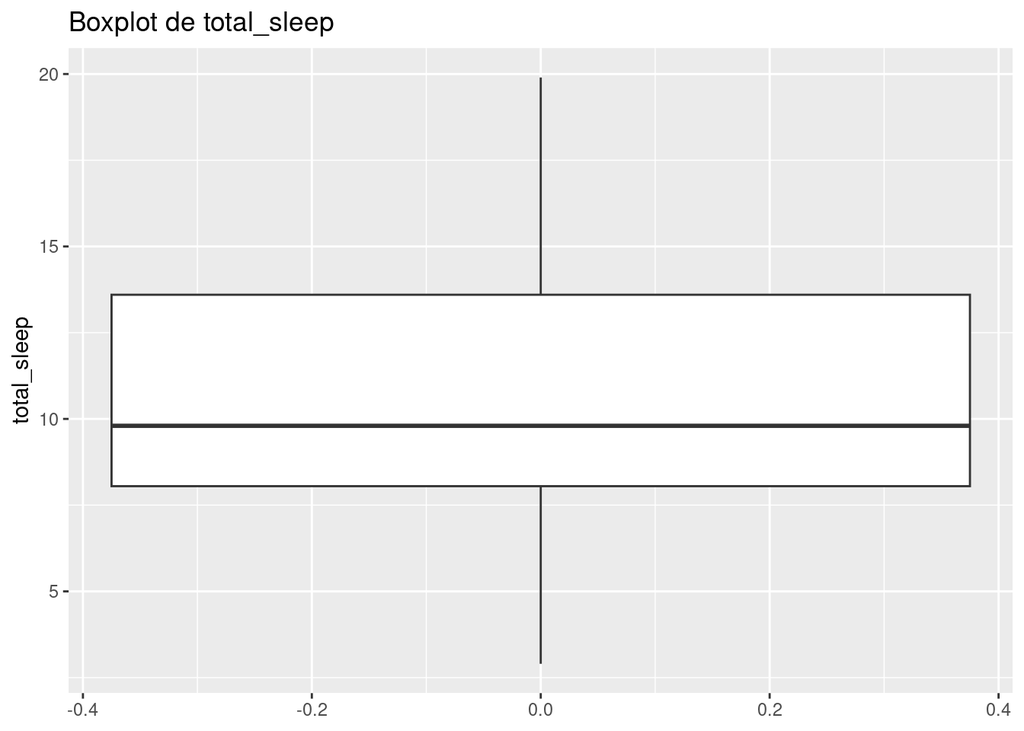

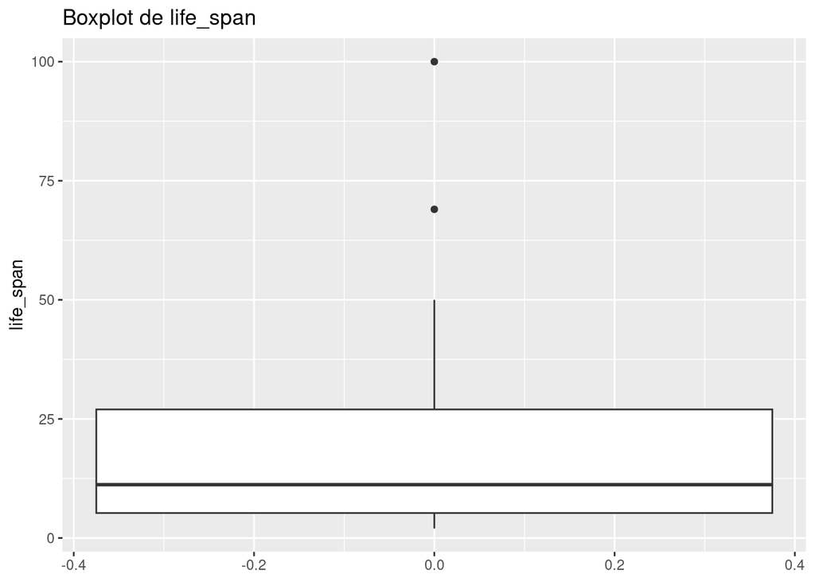

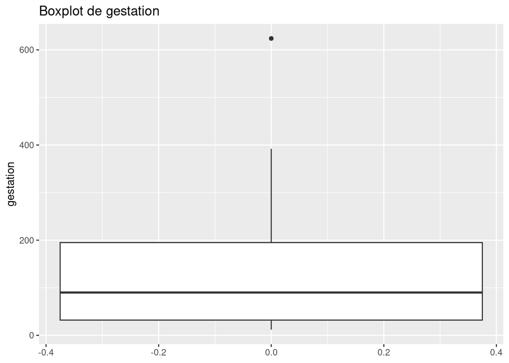

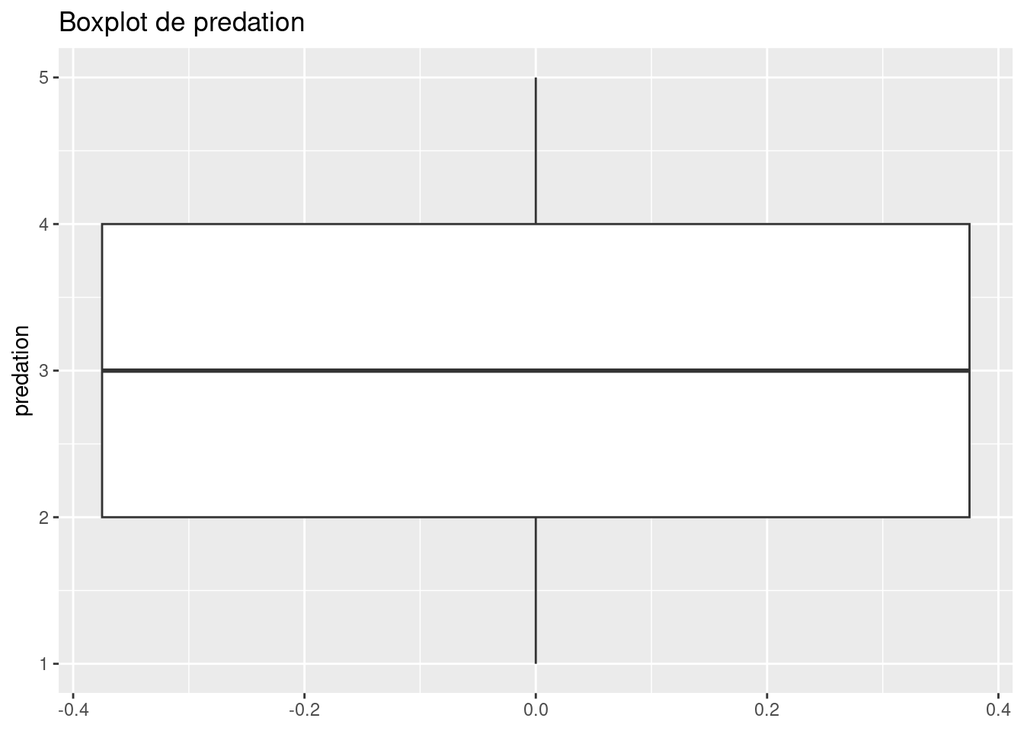

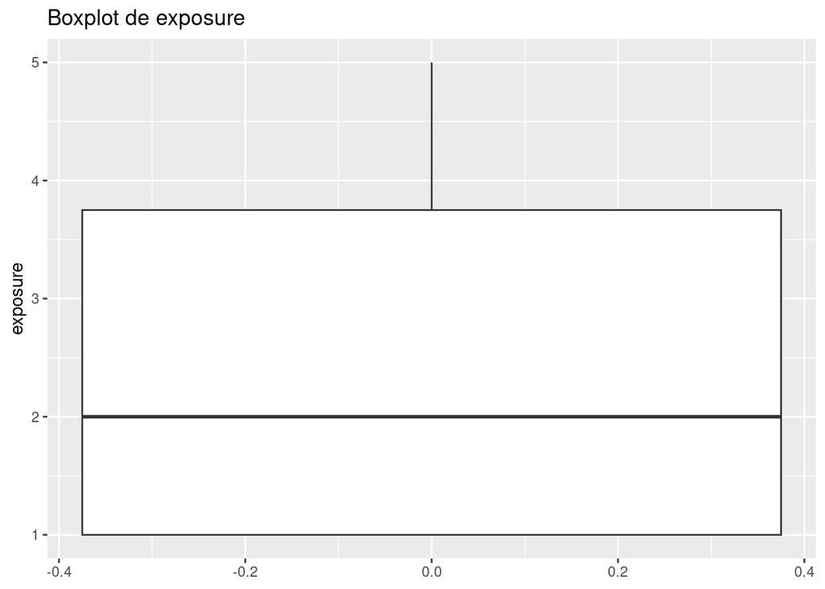

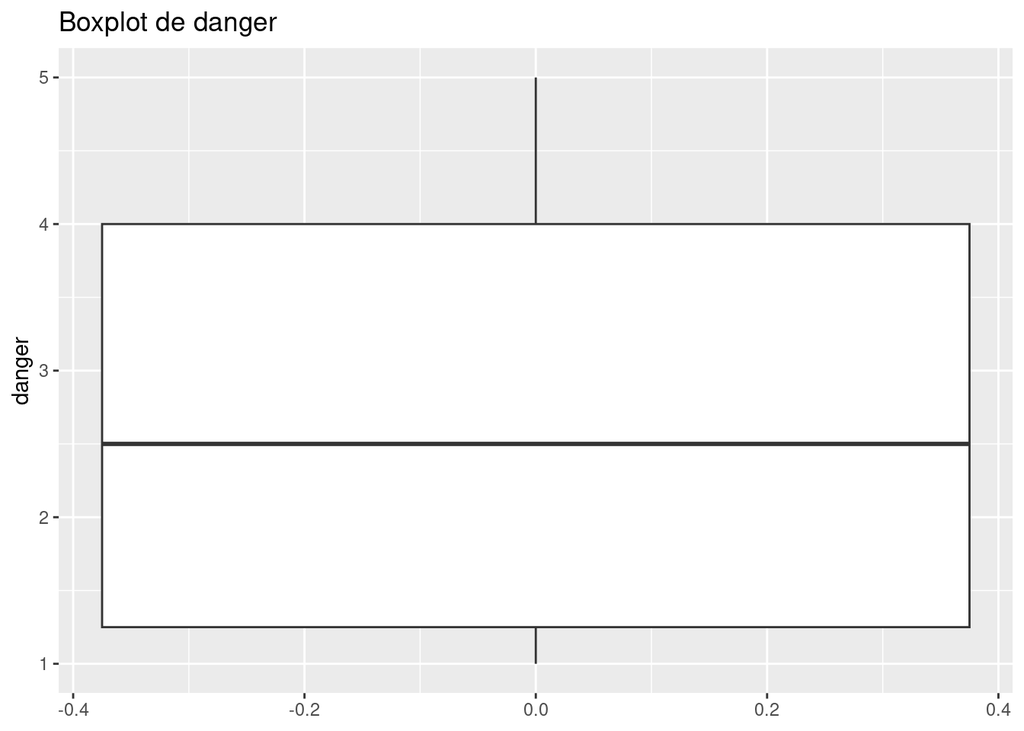

```r
for(col in names(numeric_vars)){
  print(
    ggplot(mammals_clean, aes(y = .data[[col]])) +
      geom_boxplot() +
      ggtitle(paste("Boxplot de", col))
  )
}
```

# Regressão Linear Múltipla

Como dreaming e non_dreaming são perfeitas preditoras de total_sleep, iremos retirá-las para geração do modelo.

```r
model_full <- lm(total_sleep ~ body_wt + brain_wt + life_span +
                   gestation + predation + exposure + danger,
                 data = mammals_clean)
summary(model_full)
```

```
##
## Call:
## lm(formula = total_sleep ~ body_wt + brain_wt + life_span + gestation +
##     predation + exposure + danger, data = mammals_clean)
##
## Residuals:
##     Min      1Q  Median      3Q     Max
## -6.2292 -1.8823 -0.1445  1.8914  5.9885
##
## Coefficients:
##               Estimate Std. Error t value Pr(>|t|)
## (Intercept) 17.1091251  1.3363885  12.803 1.47e-14 ***
## body_wt      0.0047024  0.0059218   0.794  0.43266
## brain_wt    -0.0009979  0.0035541  -0.281  0.78059
## life_span   -0.0145760  0.0462766  -0.315  0.75471
## gestation   -0.0188108  0.0069799  -2.695  0.01086 *
## predation    2.3151350  1.0926906   2.119  0.04150 *
## exposure     0.5844391  0.6845807   0.854  0.39924
## danger      -4.5375726  1.3567624  -3.344  0.00202 **
## ---
## Signif. codes:  0 '***' 0.001 '**' 0.01 '*' 0.05 '.' 0.1 ' ' 1
##
## Residual standard error: 3.039 on 34 degrees of freedom
## Multiple R-squared:  0.6548, Adjusted R-squared:  0.5837
## F-statistic: 9.213 on 7 and 34 DF,  p-value: 2.398e-06
```

```r
library(car)
vif(model_full)
```

```
##   body_wt  brain_wt life_span gestation predation  exposure    danger
## 25.176774 30.126322  3.902487  3.535876 11.109379  4.854897 15.746424
```

A partir da análise dos VIFs percebemos que danger, predation,brain_wt e body_wt possuem VIFs muito altos (>10), o que indica fortes sinais de multicolinearidade problemática no modelo. Portanto, iremos remover a variável com maior VIF (brain_wt), ajustar e testar o modelo novamente.

```r
model2 <- lm(total_sleep ~ body_wt + life_span +
                   gestation + predation + exposure + danger,
                 data = mammals_clean)
summary(model2)
```

```
##
## Call:
## lm(formula = total_sleep ~ body_wt + life_span + gestation +
##     predation + exposure + danger, data = mammals_clean)
##
## Residuals:
##     Min      1Q  Median      3Q     Max
## -6.2710 -1.9194 -0.2379  1.8449  5.9728
##
## Coefficients:
##              Estimate Std. Error t value Pr(>|t|)
## (Intercept) 17.134522   1.315661  13.024 5.56e-15 ***
## body_wt      0.003110   0.001679   1.852  0.07240 .
## life_span   -0.023751   0.032332  -0.735  0.46748
## gestation   -0.018975   0.006863  -2.765  0.00903 **
## predation    2.284008   1.072652   2.129  0.04034 *
## exposure     0.650782   0.633997   1.026  0.31171
## danger      -4.518409   1.337094  -3.379  0.00180 **
## ---
## Signif. codes:  0 '***' 0.001 '**' 0.01 '*' 0.05 '.' 0.1 ' ' 1
##
## Residual standard error: 2.998 on 35 degrees of freedom
## Multiple R-squared:  0.654,  Adjusted R-squared:  0.5947
## F-statistic: 11.03 on 6 and 35 DF,  p-value: 7.017e-07
```

```r
vif(model2)
```

```
##   body_wt life_span gestation predation  exposure    danger
##  2.077885  1.956458  3.510978 10.995023  4.276501 15.706574
```

Os VIFs diminuiram significativamente, mas ainda estão altos para as variáveis predation e danger. Iremos excluir danger e ver como o modelo se ajusta.

```r
model3 <- lm(total_sleep ~ body_wt + life_span +
                   gestation + predation + exposure,
                 data = mammals_clean)
summary(model3)
```

```
##
## Call:
## lm(formula = total_sleep ~ body_wt + life_span + gestation +
##     predation + exposure, data = mammals_clean)
##
## Residuals:
##     Min      1Q  Median      3Q     Max
## -6.7812 -2.0881 -0.4617  2.8893  5.5653
##
## Coefficients:
##              Estimate Std. Error t value Pr(>|t|)
## (Intercept) 17.605515   1.485567  11.851 5.52e-14 ***
## body_wt      0.002520   0.001896   1.329  0.19219
## life_span   -0.024836   0.036712  -0.676  0.50305
## gestation   -0.021407   0.007750  -2.762  0.00899 **
## predation   -0.946099   0.552710  -1.712  0.09555 .
## exposure    -0.492396   0.608873  -0.809  0.42400
## ---
## Signif. codes:  0 '***' 0.001 '**' 0.01 '*' 0.05 '.' 0.1 ' ' 1
##
## Residual standard error: 3.405 on 36 degrees of freedom
## Multiple R-squared:  0.5411, Adjusted R-squared:  0.4774
## F-statistic:  8.49 on 5 and 36 DF,  p-value: 2.2e-05
```

```r
vif(model3)
```

```
##   body_wt life_span gestation predation  exposure
##  2.055404  1.956265  3.472368  2.263995  3.058928
```

Agora os VIFs diminuiram significativamente e todos estão abaixo de 5, mas o R2 ajustado também diminuiu ( caindo de **0.58**, para **0.47**), o que não é um bom sinal.

Tendo tal resultado em mente, vamso tetar modelos mais robustos para escolher as nossas variáveis.